# Visualizing Data

## Line Charts: Nominal GDP

Let's define the data used in the line chart first. We add (optional) type signatures, and note that python lists are also valid haskell.

```haskell
years :: [Int]
years = [1950, 1960, 1970, 1980, 1990, 2000, 2010]

gdp :: [Double]
gdp = [300.2, 543.3, 1075.9, 2862.5, 5979.6, 10289.7, 14958.3]
```

### Chart: `Graphics.Rendering.Chart.Easy`

Let's try to recreate the line charts depicting the GDP by year.

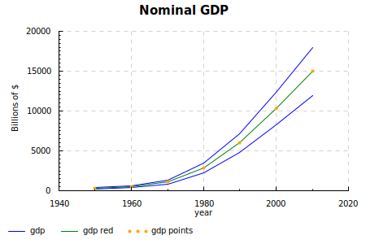

```haskell
import Graphics.Rendering.Chart.Easy

toRenderable $ do
  layout_title  .= "Nominal GDP"
  setColors [opaque blue, opaque green, opaque orange]
  layout_x_axis . laxis_title .= "year"
  layout_y_axis . laxis_title .= "Billions of $"
  plot $ line "gdp" [zip years (map (*0.8) gdp), zip years (map (*1.2) gdp)] -- two blue lines in chart
  plot $ line "gdp red" [zip years gdp] -- the green line (our real data)
  plot $ points "gdp points" $ zip years gdp
```

In contrast to `matplotlib`, the line and the points (`marker = 'o'` in the book) are plotted separately. Points must be plotted *after* the line to be plotted on top. Additionally, note that the line method accepts a list of lists of tuples, so we can draw multiple lines using the same color and legend entry. Might become useful for e.g. confidence intervals etc.

The monadic approach used for charting looks similar to the python code in the book. The increased line count can be attributed to:

- explicitely drawing the points as a separate plot
- setting the colors in a separate call (independent of the actual line chart)
- adding an `x-axis` legend and
- adding some additional lines for fun and profit.

On the plus side, `Chart` produces a legend for free.

### Non-monadic Style

We can use the `Graphics.Rendering.Chart` module directly, providing more control. See [charts documentation example 1](https://github.com/timbod7/haskell-chart/wiki/example-1). The pie chart example is not part of the book, and is certainly not a good way to represent this kind of data, but there are no pie charts in the visualization chapter, so let's just make one up!

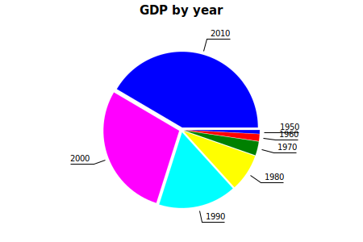

```haskell
import Graphics.Rendering.Chart
import Data.Default.Class
import Control.Lens

pitem year gdp = pitem_value .~ gdp
  $ pitem_label .~ show year
  $ pitem_offset .~ 3
  $ def

-- the full-blown chart api
toRenderable
  $ pie_title .~ "GDP by year"
  $ pie_plot . pie_data .~ zipWith pitem years gdp
  $ def
```

## Bar Charts: Hollywood

It was surprisingly hard to figure out how to properly format and align the x-axis to show string labels in a similar way to the Hollywood movie example in the book. Let's get started!

```haskell
-- define the data
movies = ["Annie Hall", "Ben-Hur", "Casablanca", "Gandhi", "West Side Story"]
num_oscars = [5, 11, 3, 8, 10]

-- a bar plot is a list of tuples, the first tuple element being the position of the
-- bar (x-axis), snd is a list of values, representing the bar heights.
barv idx val = (idx, [val]) -- each entry in num_oscars is a singleton list inside a tuple
barvs = zipWith barv [0..] num_oscars
```

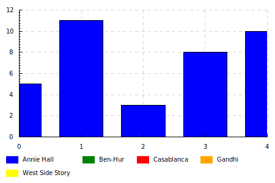

bars :: forall y x l. (BarsPlotValue y, PlotValue x) => [String] -> [(x, [y])] -> EC l (PlotBars x y)

```haskell
-- our first bar chart
toRenderable $ plot $ plotBars <$> bars movies barvs

:t bars
```

Success! There are bars, right? They even have the proper height. Still, some things are off:

- the first and last bar are not completely inside the view port
- axis labels are completely useless and not related to the actual data we want to show
- the legend shows the movie names, but the colors are not related to the bars on the chart

What's wrong? The `[String]` passed in as first argument to `bars` does not define the names for the individual bars. Instead, it is meant to be used when multiple bars are located at the same position. Additionally, we define values in the range `[0 .. 4]`, and this becomes the range that is covered by the default x-axis.

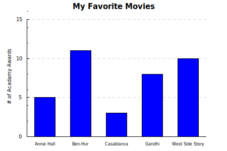

```haskell
barValues :: [(String, [Int])]
barValues = zip movies $ map (:[]) num_oscars

toRenderable $ do
  layout_title .= "My Favorite Movies"
  layout_y_axis . laxis_title .= "# of Acadamy Awards"
  layout_x_axis . laxis_generate .= autoIndexAxis (map fst barValues)
  layout_x_axis . laxis_style .= (axis_label_style . font_size .~ 8 $ def)
  plot $ plotBars <$> bars [ "" ] (addIndexes $ map snd barValues)
```

That looks a lot better. The bars are completely inside the viewport, and each bar is labelled with the name of the movie:

- we use `autoIndexAxis` with the movie names to replace the x-axis representation with a labelled one
- the font size is reduced to `8` to have enough room for each movie name. If the font is too large (or the text too long) not every label is visible.
- we pass in a singleton list with an empty string as the bar legend to suppress the legend. An empty list does *not* work, the result is an empty chart without bars.

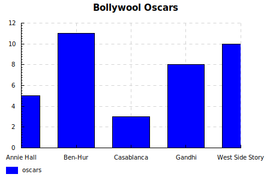

```haskell
toRenderable $ do
  layout_title .= "Bollywool Oscars"
  layout_x_axis . laxis_override .= axisLabelsOverride (zip [0..] movies)
  plot $ plotBars <$> bars ["oscars" ] barvs
```

Another attempt: replaced lambda and `autoIndexAxis` with `axisLabelsOverride` which seems to be exactly what we want: modify the existing `AxisData` by replacing the default labes with the ones passed in. However, the resulting x-axis again doesn't cover the range to fully contain all bars. Thinking about it, we took an existing axis definition and replaced the labels, so it's not surprising that this doesn't work.

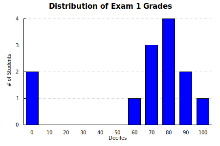

```
[(0,[2]),(10,[0]),(20,[0]),(30,[0]),(40,[0]),(50,[0]),(60,[1]),(70,[3]),(80,[4]),(90,[2]),(100,[1])]
```

```haskell
import           Data.HashMap.Strict                   (HashMap, lookupDefault, toList)
import           Data.Statistics                       (counter)
import           Data.List                             (sort)

-- data for histogram
grades :: Num a => [a]
grades = [83,95,91,87,70,0,85,82,100,67,73,77,0]

decile :: Integral a => a -> a
decile n = n `div` 10 * 10


decileGrades :: HashMap Int Int
decileGrades = counter decile grades

barvsDeciles :: [(Int, [Int])]
barvsDeciles = map (\k -> (k , [lookupDefault 0 k decileGrades])) [0, 10 .. 100]

bars' = plot_bars_values .~ addIndexes (map snd barvsDeciles)
      $ plot_bars_style  .~ BarsClustered -- is default, irrelevant for single bars
      $ plot_bars_alignment .~ BarsCentered
      $ def


layout = layout_title .~ "Distribution of Exam 1 Grades"
       $ layout_x_axis . laxis_title .~ "Deciles"
       $ layout_x_axis . laxis_generate .~ autoIndexAxis (map (show . fst) barvsDeciles)
       $ layout_y_axis . laxis_title .~ "# of Students"
       $ layout_plots .~ [ plotBars bars' ]
       $ def

toRenderable layout

barvsDeciles
```

We use a similar approach as in the previous bar chart. Using this approach, it's necessary to define the input data containing also the bars with zero height, because our x-axis values are not based on the actual decile values, but built using `addIndexes`.

`Chart` also supports plotting [Histograms](https://hackage.haskell.org/package/Chart-1.9/docs/Graphics-Rendering-Chart-Plot-Histogram.html). Let's give it a try...

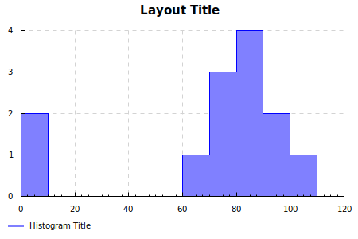

```haskell
histPlot :: PlotHist Double Int
histPlot = plot_hist_title .~ "Histogram Title"
         $ plot_hist_bins .~ 11
         $ plot_hist_values .~ grades
         $ plot_hist_range .~ Just (0, 110)
         $ def

histLayout :: Layout Double Int
histLayout = layout_title .~ "Layout Title"
           $ layout_plots .~ [ histToPlot histPlot ]
           $ def

toRenderable histLayout
```

This is nice in the sense that we don't need our `counter` functionality. However, this doesn't look quite right. We had to create 11 bins, and to make each bucket width 10, the overall range had to be from zero to 110. This, in turn, leads to an overall x-axis that is too wide. Additionally, the bars are not centered around the deciles, so it's slightly misleading.

## Bar Charts - misleading Axis

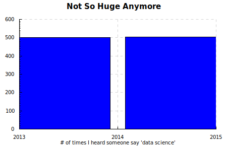

```haskell
mentions = [[500], [505]]
years    = [2013, 2015]

toRenderable $ do
  layout_title .= "Not So Huge Anymore"
  layout_x_axis . laxis_title .= "# of times I heard someone say 'data science'"
  plot $ plotBars <$> bars [""] (zip years mentions)
```

The misleading y-axis is actually hard to reproduce, there's no obvious way to create a bar chart that does not start at zero. We consider this a feature, given that the book argues that any bar chart not starting at zero is *especially bad form*.

# Line Charts

This is a small variation on the line charts at the top, so there's not too much to be said here.

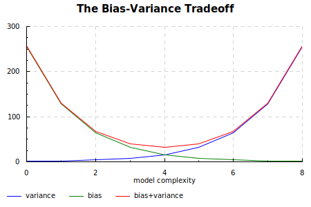

```haskell
variance, biasSquared, totalError :: [Int]
variance     = [1,2,4,8,16,32,64,128,256]
biasSquared = [256,128,64,32,16,8,4,2,1]
totalError  = zipWith (+) variance biasSquared

toRenderable $ do
  layout_title .= "The Bias-Variance Tradeoff"
  layout_x_axis . laxis_title .= "model complexity"
  plot $ line "variance" [zip [0..] variance]
  plot $ line "bias"     [zip [0..] biasSquared]
  plot $ line "bias+variance" [zip [0..] totalError]
```

However, the plot doesn't use dotted lines. Let's change this.

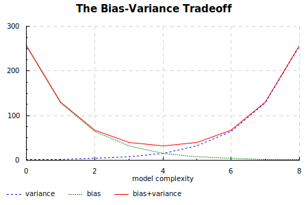

```haskell
variance, biasSquared, totalError :: [Int]
variance     = [1,2,4,8,16,32,64,128,256]
biasSquared = [256,128,64,32,16,8,4,2,1]
totalError  = zipWith (+) variance biasSquared

toRenderable $ do
  layout_title .= "The Bias-Variance Tradeoff"
  layout_x_axis . laxis_title .= "model complexity"
  let l1 = line "variance" [zip [0..] variance]
  plot $ (plot_lines_style . line_dashes .~ [2, 4]) <$> l1
  plot $ (plot_lines_style . line_dashes .~ [1, 2]) <$> line "bias" [zip [0..] biasSquared]
  plot $ line "bias+variance" [zip [0..] totalError]
```

Here's a similar version without the `Easy` module and the stateful monadic API.

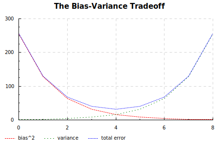

```haskell
lineLayout :: Layout Int Int
lineLayout = layout_title .~  "The Bias-Variance Tradeoff"
       $ layout_plots .~ map toPlot [biasLinePlot, varianceLinePlot, totalErrorPlot]
       $ def
  where
    varianceLinePlot = plot_lines_style . line_dashes .~ [1, 5] $
                       plot_lines_title .~ "variance" $
                       plot_lines_style . line_color  .~ opaque green $
                       plot_lines_values .~ [ zip [0..] variance] $
                       def

    biasLinePlot = plot_lines_style . line_dashes .~ [2] $
                   plot_lines_title .~ "bias^2" $
                   plot_lines_style . line_color  .~ opaque red $
                   plot_lines_values .~ [ zip [0..] biasSquared] $
                   def

    totalErrorPlot = plot_lines_style . line_dashes .~ [1, 2] $
                     plot_lines_title .~ "total error" $
                     plot_lines_style . line_color  .~ opaque blue $
                     plot_lines_values .~ [ zip [0..] totalError] $
                     def


toRenderable lineLayout
```

While the plot definitions themselves get more verbose when using the `Graphics.Rendering.Chart` module directly, it's actually easier to read (and write). A real application would most probably pre-define certain line styles, or even entire line charts, accepting a small number of parameters (`values`, `line_style`, `title`).

# Scatterplots

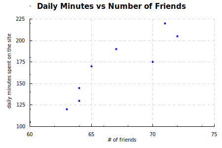

```haskell
friends, minutes :: Num a => [a]
friends = [ 70, 65, 72, 63, 71, 64, 60, 64, 67]
minutes = [175, 170, 205, 120, 220, 130, 105, 145, 190]

labels :: [Char]
labels = ['a', 'b', 'c', 'd', 'e', 'f', 'g', 'h', 'i']

scatterPlot :: Renderable ()
scatterPlot = toRenderable $ do
  layout_title .= "Daily Minutes vs Number of Friends"
  layout_x_axis . laxis_title .= "# of friends"
  layout_y_axis . laxis_title .= "daily minutes spent on the site"
  plot $ points "" $ zip friends minutes

scatterPlot
```

Basic scatterplot: `plot $ points "" $ zip x y`. The example in the book also prints a label next to each point. I wasn't able to reproduce that using the monadic API, so I used the other one:

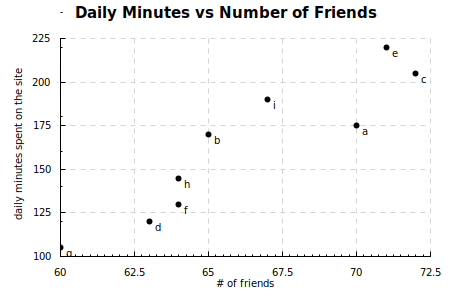

```haskell
scatterPlot :: Renderable ()
scatterPlot = toRenderable annotatedPoints
  where
    annotatedPoints =
      layout_title .~ "Daily Minutes vs Number of Friends" $
      layout_x_axis . laxis_title .~ "# of friends" $
      layout_y_axis . laxis_title .~ "daily minutes spent on the site" $
      layout_plots .~ [toPlot pointsPlot, toPlot texts] $
      def
    pointsPlot = plot_points_values .~ zip friends minutes $
                 plot_points_style . point_radius .~ 3 $
                 def
    texts = plot_annotation_values .~ zip3 ((+0.2) <$> friends) minutes ((:[]) <$> labels) $
            plot_annotation_hanchor .~ HTA_Left $
            plot_annotation_vanchor .~ VTA_Top $
            def

scatterPlot
```

It's necessary to shift the placements of the labels a little to avoid overlapping the letter and the point. The letter is aligned to the given place with it's top-left corner (`HTA_Left` and `VTA_Top`) but I couldn't find a way to displace the text directly. Note how the (+0.2) changes the type of the Plot, leading to a x-axis with non-integral values.

### TODO: use monadic API

The example above doesn't make use of the monadic API, so it's rather verbose. I couldn't get it to work using the monadic API. For the `PlotAnnotation` type, there's no predefined method like `points` or `lines`, and I wasn't able to make the stars types align with text inside the `do` block.

## Scatterplots: mind your axes

This example illustrates the effects of having comparable types on both the x-axis and the y-axes, without also providing similar value ranges for them.

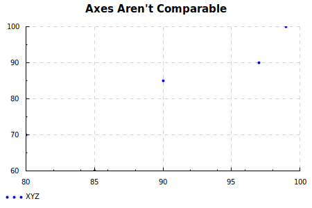

```haskell
test1Grades, test2Grades :: Num a => [a]
test1Grades = [ 99, 90, 85, 97, 80]
test2Grades = [100, 85, 60, 90, 70]

scatterplotUnequalAxes = toRenderable $ do
  layout_title .= "Axes Aren't Comparable"
  plot $ points "XYZ" $ zip (test1Grades :: [Int]) (test2Grades :: [Int])

scatterplotUnequalAxes
```

Well... almost. Some of the points are directly on either the grid or the ticks, making them almost hidden. This seems to be a general theme: `Chart` produces axis whose range seems to be rounded to the nearest *round* number (here: x-axis `[80, 100]`, y-axis `[60, 100]`). However, it does not incorporate some minimal gap between the axis range and the value range, so values can lead exactly on the axis.

We try to improve on this chart by adding a hidden plot underneath it, with slightly increased value ranges to force all points to be strictly inside the viewport.

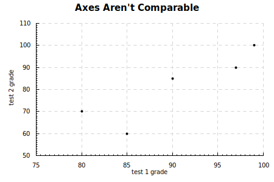

```haskell
data AxisRange a = AxisRange a a deriving (Show, Eq)

-- scatter plot combining a point plot with a hidden plot to enlarge the
-- viewport somewhat, otherwise some points lay directly on the axis and ticks.
scatterplotUnequalAxes :: Renderable ()
scatterplotUnequalAxes = toRenderable unequalScatterLayout
  where
    AxisRange minX maxX = scaleRange 1.1 $ computeRange (test1Grades :: [Double])
    AxisRange minY maxY = scaleRange 1.1 $ computeRange (test2Grades :: [Double])
    hidden = PlotHidden { _plot_hidden_x_values = [minX, maxX]
                        , _plot_hidden_y_values = [minY, maxY] }
    pointPlot = plot_points_values .~ zip (test1Grades :: [Double]) (test2Grades :: [Double]) $
                plot_points_style . point_radius .~ 2 $
                def
    unequalScatterLayout = layout_title .~ "Axes Aren't Comparable" $
                           layout_x_axis . laxis_title .~ "test 1 grade" $
                           layout_y_axis . laxis_title .~ "test 2 grade" $
                           layout_plots .~ [toPlot pointPlot, toPlot hidden] $ def

-- | produce a range that scaled by `factor`.
scaleRange :: Fractional a => a -> AxisRange a -> AxisRange a
scaleRange factor (AxisRange minV maxV) =
  let middle = (maxV + minV) / 2
  in AxisRange (middle - (middle - minV)*factor) (middle + (maxV - middle)*factor)

computeRange :: Ord a => [a] -> AxisRange a
computeRange xs = AxisRange (minimum xs) (maximum xs)

scatterplotUnequalAxes
```

Looks okay-ish. There's substantial whitespace on both axis, but that's a feature of the underlying axis generator logic. As a next step, we make the axis ranges equal, which is unfortunately a lot more involved than matplotlib's `plt.axis("equal")`.

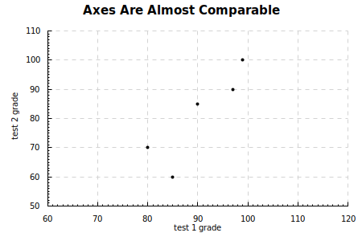

```haskell
-- | given two ranges, produce new set of ranges that have equal width
alignRanges :: (Fractional a, Ord a) => AxisRange a -> AxisRange a -> (AxisRange a, AxisRange a)
alignRanges x@(AxisRange minX maxX) y@(AxisRange minY maxY)=
  let
    xRange = maxX - minX
    yRange = maxY - minY
    range  = max xRange yRange
    newXrange = if range == xRange then x else scaleRange (range / xRange) x
    newYrange = if range == yRange then y else scaleRange (range / yRange) y
  in (newXrange, newYrange)

scatterplotEqualAxes :: Renderable ()
scatterplotEqualAxes = toRenderable layout
  where
    xRange = scaleRange 1.1 $ computeRange (test1Grades :: [Double])
    yRange = scaleRange 1.1 $ computeRange (test2Grades :: [Double])
    (AxisRange minX maxX, AxisRange minY maxY) = alignRanges xRange yRange
    hidden = PlotHidden { _plot_hidden_x_values = [minX, maxX]
                        , _plot_hidden_y_values = [minY, maxY] }
    pointPlot = plot_points_values .~ zip (test1Grades :: [Double]) (test2Grades :: [Double]) $
                plot_points_style . point_radius .~ 2 $
                def
    layout = layout_title .~ "Axes Are Almost Comparable" $
             layout_x_axis . laxis_title .~ "test 1 grade" $
             layout_y_axis . laxis_title .~ "test 2 grade" $
             layout_plots .~ [toPlot pointPlot, toPlot hidden] $ def

scatterplotEqualAxes
```

Quite a bit of code for such a basic requirement. The x-axis and the y-axis cover the same range, but they don't have the same scaling, because the plot itself is wider than tall. Using `PlotHidden` in combination with `scaleRange` could be used to manually adjust the axis to your liking.

## TODO / Open Issues

- the chart about misleading axis is missing. I have no idea how to create a bar chart that doesn't start from zero
- the chart *Axis Are Comparable* is missing.